# 如何用 R Markdown 写学术文档？

WSJ

College of Economics，Shenzhen University

2018-09-17

# 1 介绍

## 1.1 什么是R Markdown？

R Markdown (Allaire et al. 2018) 是结合Markdown和R(R Core Team 2018)语言的写作软件。

Markdown是轻量级、纯文本、超简单的书写格式。

R Markdown可以做什么？

- 语法简单。作者基本上无需关心排版问题，只要专心写作就可以了。
- 计算结果动态生成。作者不必手动拷贝粘贴代码结果或者生成的表格、图片等。
- 易于修改。写作过程中如需修改某处，全文相应变动会自动生成，包括软件运行的结果（图形等）。
- 比Word更美观，比LaTeX更易用。
- 方便地插入目录、图表、脚注等。Bookdown扩展功能可以交叉引用、索引。
- 方便地插入数学公式、参考文献、R代码。
- 可以生成漂亮的pdf、word、epub、网页和幻灯片等多种文件格式。
- 写作及结果具有可重复性。
- 支持多语言，包括 R, C/C++, Python, Fortran, Julia, Shell scripts和 SQL等。
- R 和 Markdown 都是开源免费的。

Rmarkdown 使得数据分析代码可以与文档混编，具体语法请参看《R Markdown语法简介》。

下面是回归模型的简单例子。在R中，回归模型可以用非常简单的一行代码搞定：`lm(y~x, data)`，

```r
options(digits = 4)
fit = lm(dist ~ speed, data = cars)
coef(summary(fit))
```

```
            Estimate Std. Error t value  Pr(>|t|)
(Intercept)  -17.579     6.7584  -2.601 1.232e-02
speed          3.932     0.4155   9.464 1.490e-12
```

```r
b = coef(fit)
```

上面回归方程中的斜率是3.9324，完整的回归方程为：
$$Y = -17.5791 + 3.9324x$$

散点图和回归直线：

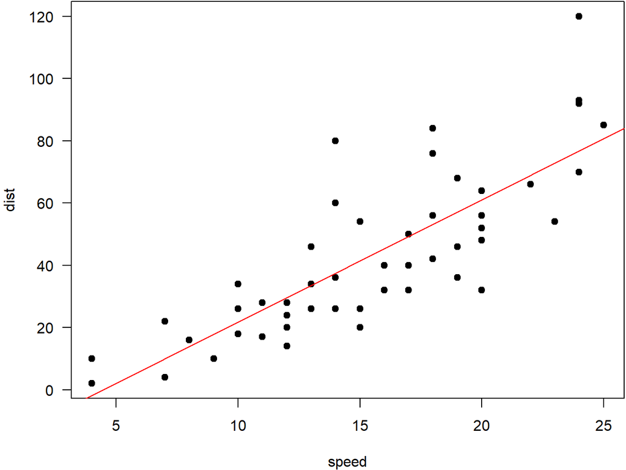

Figure 1.1: cars数据散点图以及回归直线。

```r
par(mar = c(4, 4, .1, .1), las = 1)
plot(cars, pch = 19)
abline(fit, col = 'red')
```

## 1.2 系统环境

需要安装的软件：

- R：https://www.r-project.org/
- RStudio：https://www.rstudio.com/
- Bookdown：https://bookdown.org/

安装Bookdown (Xie 2018a)及其相依软件包基本上就OK了，包括了rmarkdown (Allaire et al. 2018)、knitr (Xie 2018b)、 rticles等，如果有缺失的，运行时会提示安装。

可以安装稳定版: `install.packages(’bookdown’)`

或开发版: `devtools::install_github('rstudio/bookdown')`

## 1.3 RStudio基本设置

打开 Tools→global options，然后

- 点击`sweave`，在`weave rnw files using`选择 **knitr**
- 在`Typeset LaTex into PDF using` 选择**XeLaTex**
- 在`Code -> Saving -> Default text Encoding` 选择 `UTF-8`

# 2 用 R Markdown 写简单学术文档

所谓“简单”学术文档，是指满足了学术文档的基本要求，包括标题、公式、图表、参考文献以及自动编号等，但是不能交互引用。这种情况下 RMarkdown 具有独特优势，可以直接上手，输出结果丰富。

1. 新建一个R Markdown 文档。在打开界面可输入题目和作者姓名，输出格式可选择`html`，`pdf` 或 `word`。
2. 简单设置。点击`Knit`旁边的齿轮按钮，在`Output Options`可做更多选择，比如可勾选`Include table of contents`，表示建立目录。勾选`Number section headings`表示章节题目包含顺序数字。在`Figures`勾选`Render figure captions`表示图形会显示标题并自动排序。
3. 结果输出。
- 如果文档是**纯英文**的，可以通过 `knit` 转为 `html`，`pdf` 或 `word` 任何格式都没问题。不过，如果你用中文Windows，则日期最好用 `` "` r Sys.Date() `" `` 代替或直接输入英文日期，否则可能会乱码。
- 如果文档是**中文**的，则
  - 转 `html` 没有任何问题。
  - 转`word`，一定要在开始时指定，或在文档的`output:`下面指明`word_document:`，否则标题和日期会是乱码。
  - 中文文档不能直接转`pdf`。

**中文文档如何转`pdf`？**

要转为 pdf文档，必须安装软件包`rticles`。用法很简单：打开 Rmarkdown时，选择 `From Template`，从模版中选择 `CTex Documents`即可。

一般文档开头（称为`yaml`）是这样的：

```markdown
---
title: "你的论文题目"
author: "你的姓名"
date:  "2018-09-17"
output:
  html_document:                           #文档格式为html
    fig_caption: yes                       #包括图形标题
    number_sections: yes                   #章节数字顺序
    toc: yes                               #显示目录
    toc_depth: 3                           #三级目录
    toc_float: True                        #目录作为侧边栏
bibliography: reference.bib                #参考文献文件名
bibli0-style: apalike                      #参考文献格式
link-citations: yes                        #参考文献链接
colorlinks: yes                            #链接颜色
#lot: yes                                  #表格列表
#lof: yes                                  #图形列表
---
```

# 3 用 R Markdown 写学术文档

前面介绍的R Markdown文档是没有**交叉引用**功能的，即公式、图形、表格或章节之间在正文的引用不能自动编号。

为了实现交叉引用功能，可以扩展到`bookdown`。

**撰写可以交叉引用的网页文档**：

把`html_document:`换成`bookdown::html_document2:`即可，其它不变。

**撰写可以交叉引用的pdf文档**：

如果文档是**纯英文**的，把`html_document:`换成`bookdown::pdf_document2:`即可，其它不变。 如果文档含有中文字符，还是老老实实用软件包bookdown或bookdownplus吧。

**撰写可以交叉引用的docx文档**：

一样把`word_document:`换成`bookdown::word_document2:`。但是直接产生的word文档格式不一定满足要求，如标题是蓝色的等等。

可以制作一个**参考文档**：由R Markdown产生一个 word文档，然后对该文档的**样式**进行编辑（编辑其它功能无效）。

我已经编辑了一个参考文档：word_style.docx，你可以结合需要自行再通过*样式*修改。

我的 `yaml`是这样的：

```markdown
---
title: "Word 参考文档"
author:
  - WSJ
  - College of Economics，Shenzhen University
date:  "2018-09-17"
output:
  bookdown::word_document2:
    reference_docx: template/word_style.docx
    fig_caption: yes
bibliography: [bib/packages.bib,bib/book.bib]
csl: csl/chinese-gb7714-1987-numeric.csl
#bibli0-style: apalike
link-citations: yes
colorlinks: yes
#lot: yes
#lof: yes
---
```

**如何修改参考文献格式？**

注释掉 `#bibli0-style: apalike`， 然后增加一行：

csl: csl/chinese-gb7714-1987-numeric.csl

# 4 用Bookdown写书或长文

长篇论文（书籍、毕业论文）需要分章节以及交叉引用，结构复杂，简单的一个Rmarkdown文档可能不能胜任。

一本 **bookdown** 书含有多个章节，每个章节写在单独的`.Rmd` 文件，起始部分为该章节标题 `# Chapter Title`。

如果含有中文，所有 R Markdown 文档都必须用 UTF-8编码保存。

以下是一本书的典型例子：

- index.Rmd

  ```markdown
  # Preface {-}

  In this book, we will introduce an interesting
  method.
  ```

- 01-intro.Rmd

  ```markdown
  # Introduction

  This chapter is an overview of the methods that
  we propose to solve an **important problem**.
  ```

- 02-literature.Rmd

  ```markdown
  # Literature

  Here is a review of existing methods.
  ```

- 03-method.Rmd

  ```markdown
  # Methods

  We describe our methods in this chapter.
  ```

- 04-application.Rmd

  ```markdown
  # Applications

  Some _significant_ applications are demonstrated
  in this chapter.

  ## Example one

  ## Example two
  ```

- 05-summary.Rmd

  ```markdown
  # Final Words

  We have finished a nice book.
  ```

**具体用法**：

- 下载模板：在模板下载网页（github）的右上角，点击`Clone or download` 下载压缩文件，解压到工作目录。
  - 英文模版 https://github.com/rstudio/bookdown-demo。
  - 中文模版https://github.com/yihui/bookdown-chinese
- 用RStudio打开文件`bookdown-demo.Rproj`或`bookdown-chinese.Rproj`，然后在右上角点击`Build`，下一行`Build Book`，然后选择相应格式 (pdf,epub,word,gitbook) 即可得到模板文件。
- 根据自己需要修改相关文件，保存。运行`Build Book`即可得到你自己的书籍。

其中中文书可输出格式 `gitbook`网页、`pdf`, `word` 和 `epub`。

英文的demo里默认没有 `word`格式的输出，要自行在`_output.yml`里添加一行：

`bookdown::word_document2: default`

更多说明请参看 Xie Yihui（2018）：*bookdown: Authoring Books and Technical Documents with R Markdown* (https://bookdown.org/yihui/bookdown/)

# 5 用 Bookdownplus 模版快速上手

Bookdownplus(Zhao 2017) 对Bookdown进行了重新配置，制作了多种文本的模版，包括中、英文论文，北大、浙大等高校毕业论文等，大大方便了各种类型的写作应用。

## 5.1 安装调用

软件包bookdownplus 可参看 `CRAN` https://cran.r-project.org/web/packages/bookdownplus/index.html。 也可以到`Github` https://github.com/pzhaonet/bookdownplus 去下载相关文件。

安装稳定版:`install.packages(’bookdownplus’)`

或开发版:`devtools::install_github('pzhaonet/bookdownplus')`

调用软件包：

```r
require(bookdownplus)
```

查看所有可用模版：

```r
template()
 [1] "article"         "article_mdpi"    "article_zh"
 [4] "calendar"        "cchess"          "chemistry"
 [7] "chemistry_zh"    "discussion"      "dnd_dev"
[10] "docsens"         "guitar"          "igo"
[13] "journal"         "mail"            "musix"
[16] "nonpar"          "nte_zh"          "poem"
[19] "poster"          "rbasics"         "skak"
[22] "thesis_classic"  "thesis_mypku_zh" "thesis_pku_zh"
[25] "thesis_ubt"      "thesis_zju_zh"   "yihui_crc"
[28] "yihui_demo"      "yihui_mini"      "yihui_zh"
```

其中 `article` 是英文版学术论文模版，`article_zh` 是中文学术论文模版，`thesis_pku_zh` 是北京大学毕业论文模版，`thesis_zju_zh` 是浙江大学的。

## 5.2 用 Bookdownplus撰写论文

**步骤**：

1. 产生模版。首先把RStudio的工作目录设置在一个空白的文件夹（`Session -> Set Working Directory -> Choose Directory`，也可以通过快捷键选取 `Ctrl + Shift + H`）。 执行 `library("bookdownplus")` `bookdownplus(template = "article_zh",rproj=TRUE)`  
   其中 `rproj=TRUE` 必须加上，否则不会产生`bookdownplus.Rproj`文件。
2. 在`index.Rmd`修改题目、作者等，在`body.Rmd` 撰写正文。
3. 创建你的论文。在RStudio中打开`bookdownplus.Rproj`，在右上角点击`Build`，下一行`Build Book`，然后选择相应格式 (pdf,epub,word,gitbook) 即可。你的论文在文件夹 `_book` 里面。

其它格式（书籍、毕业论文、杂志文章等）类似，请自行测试。

# 6 修改中文参考文献样式

不管是 Bookdown 还是 Bookdownplus，默认参考文献的引用格式都是 apalike，引用格式是`作者-年`，不符合gb7714中文标准。

## 6.1 修改 Bookdownplus

- 到 csl样式库 https://www.zotero.org/styles 下载合适的样式（有几百种），放在**工作目录**。 比如 chinese-gb7714-1987-numeric.csl；
- 在文件`index.rmd` 中:
  - 修改 `natbib` 为 `none`；
  - 把`pandoc_args:` 后面内容替换为：`[ "--top-level-division=chapter", "--csl","chinese-gb7714-1987-numeric.csl" ]`;
  - 删除或注释掉文档`index.Rmd` 中的`biblio-style: apalike`；
- 在`body.Rmd` 的最后增加一行：`## 参考文献 {-}`。

## 6.2 修改Bookdown

### 6.2.1 修改任意样式

- 在文件`_output.yml` 中修改 `citation_package: none`；
- 在文件`_output.yml` 各种格式(gitbook, pdf_book, epub_book) 中增加 `pandoc_args: [ "--csl","your-csl-file.csl" ]`；
- 删除或注释掉文档`index.Rmd` 中的`biblio-style: apalike`；
- 把文件`08-references.Rmd` 首行改为 `# 参考文献 {-}`（否则参考文献不出现）。

### 6.2.2 修改中文样式

修改 _output.yml中 `pandoc_args: [ "--top-level-division=chapter", "--csl", "chinese-gb7714-1987-numeric.csl" ]`

为了试试中文的引用，我通过Zotero产生一个bibtex文献（注意中文引用显示为–，需要自行修改）(柯忠义 2017)。

# 参考文献

Allaire, JJ, Yihui Xie, Jonathan McPherson, Javier Luraschi, Kevin Ushey, Aron Atkins, Hadley Wickham, Joe Cheng, and Winston Chang. 2018. *Rmarkdown: Dynamic Documents for R*. https://CRAN.R-project.org/package=rmarkdown.

R Core Team. 2018. *R: A Language and Environment for Statistical Computing*. Vienna, Austria: R Foundation for Statistical Computing. https://www.R-project.org/.

Xie, Yihui. 2018a. *Bookdown: Authoring Books and Technical Documents with R Markdown*. https://CRAN.R-project.org/package=bookdown.

———. 2018b. *Knitr: A General-Purpose Package for Dynamic Report Generation in R*. https://CRAN.R-project.org/package=knitr.

Zhao, Peng. 2017. *Bookdownplus: Generate Varied Books and Documents with R ’Bookdown’ Package*. https://CRAN.R-project.org/package=bookdownplus.

柯忠义. 2017. “创业板上市公司经济绩效及影响因素——基于贝叶斯模型平均法 (BMA) 的实证研究.” *数量经济技术经济研究* 34 (1): 146–60.